# Bird Observations in the Auckland Region

## Data Collection - Why? What? How?

New Zealand - including the Auckland Region - is home to many native and introduced bird species. Many of us interact with birds everyday without even realising their importance for the New Zealand ecosystem. I was interested in learning about the distribution of birds across the Auckland Region.

To gather my desired information about birds, I created a google form that had questions about number, type, and locations of birds - [the survey can be found here](https://docs.google.com/forms/d/e/1FAIpQLSeaxvYp4pD63_Az25_sagrAra6Mi-5BuKtCx4qVNIiky3N4cA/viewform?usp=sharing). The form was filled out multiple times a day across a couple of weeks whenever I was outside.

I ended up gathering data for 41 observation periods. In the end I had a variety of information, but for my analysis I decided to focus on:

- Types of Species
- Total Bird Numbers
- Native vs Introduced Bird Numbers
- Locations of Observations
- Time of Day

## How does the number of birds change throughout the day?

To start I looked out how the distribution of the total number of birds varied throughout the day. I created a boxplot overlayed with the individual data points. Each of the boxes represents a time of day and the associated bird numbers.

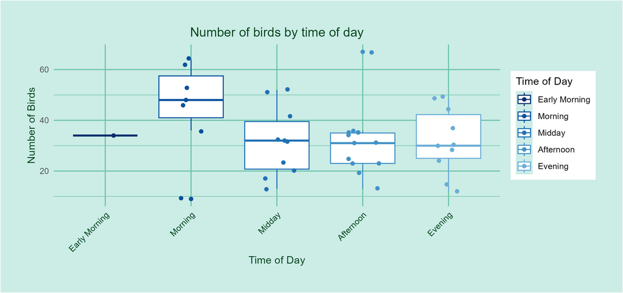

A boxplot with ‘Time of Day’ along the x-axis, and ‘Number of Birds’ along the y-axis. Points are overlayed to show specific bird numbers for each observation.

From the plot we it can be seen that the median bird number is very similar for observations during the early morning, midday, afternoon, and evening, but, appears to be much higher for morning observations. The results may suggest that birds are generally most active during the morning meaning we observe more of them. However, it is important to note that our two lowest bird counts were both in the morning, while our two highest bird counts were in the afternoon; so we probably need more data before we make any claims.

## Are there any differences in numbers of birds at different location type? How does this differ between Native and Introduced species?

Next I analysed how the number of birds was related to the area in which observations took place. I was interested in how this may be different between native vs introduced species so divided the groups when making the plot. I used a count plot to display this data, and added a red diamond to show the mean number of birds for each location. The size of the point indicates that number of observations that reported the same number of birds.

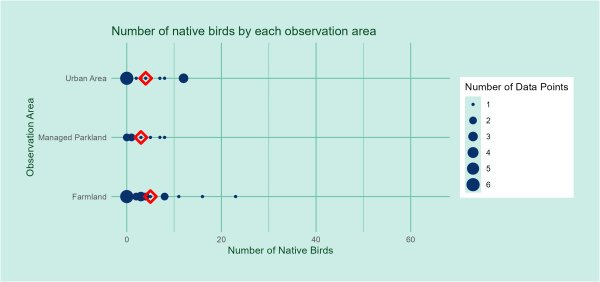

An animated count plot showing the number of native vs introduced bird at each area observations took place. The plot starts off showing the native bird counts before the animation morphs it into the introduced bird count. Each count has a red diamond indicating the mean number of birds seen for each area

From the plot animation we can see that the number of introduced birds is much higher than the number of native birds. The plot shows that it was not unusual for 0 native birds to be seen. The means for each observation area are very similar for the native birds with means being 4 for **urban area**, 3 for **managed parkland** and 5 for **farmland**. The highest count of native birds was seen on farmland with a count of 23.

The number of introduced birds being reported is much higher than the number of native birds. The observation area with the highest mean number of birds was **farmland** which had a mean of 35; **managed parkland** had a mean of 28, while, **urban area** had the lowest mean of 23. The highest count of introduced birds was seen on farmland with a count of 61.

## Thats a lot of birds…so what species did we actually see?

Finally I was interested in what types of species were being seen. To see what species were observed I created a bar chart that showed the types of birds and number of observations period in which the were reported to be seen. I wanted to visualise what species were introduced vs which were native so I filled the bars to show this.

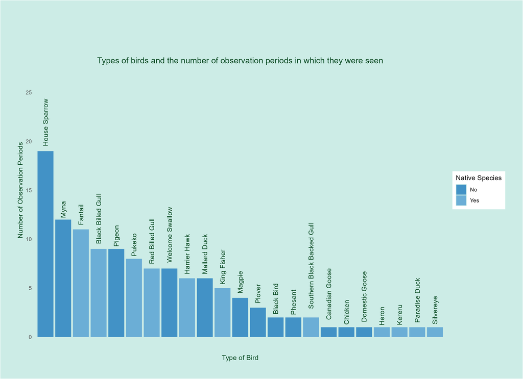

Bar chart showing the types of birds and the number of observation period in which they were reported being seen. The type of bird is along the x-axis and number of obsersavations along the y-axis. The bars are coloured showing if the species is native or not.

Overall 23 different species were seen across the 41 observation periods. Of these species 12 were introduced while 11 were native.

## What does this all mean?

From the data that has been collected. It appears that:

1. The number of birds appears to be greatest in the morning.
2. The number of introduced birds in higher across all observation areas.
3. More introduced species were seen than native species.

These results show how despite the importance of our native birds we actually do not see many within the Auckland region. There was no data collected for observations in native bush areas, so it is possible that these areas may have a higher proportion of native species - this may be a good thing to investigate in the future.